# Association Analysis

```r
library(dplyr)
library(data.table)
```

```r
library(ggplot2)
library(parallel)
library(glue)
library(tidyr)
```

## Background

- get PCs
- get depression status
- identify individuals who did not have depression at baseline
- Read in PRS scores for each ancestry, and protein levels
- Regress protein ~ PRS for each protein and ancestry, including covariates
- Lookup agreement of assocs across ancestries
- Regression in controls only (i.e. excluding individuals who had first episode before enrollment date)

## Notes

- AFR, SAS, EAS have low power, so if you find a protein assoc in those populations, it’s quite interesting to see if they don’t associate in EUR because EUR have so much power
- For each of AFR, SAS and EAS, select their significant proteins, and perform heterogeneity (like in rcovs_sig2), to see if there’s any evidence that these are ancestry specific
- For EUR, we’re finding almost half of tested proteins actually have an association. If we don’t see heterogeneity for the EUR associations, it suggests that there’s a widespread effect in all ancestries, it’s not just EUR
- Manhattan plot or something that shows Q for each significant protein
- Look at heterogeneity of SAS, AFR, EAS discovered proteins - this will reduce multiple testing
- For anything that shows heterogeneity, plot the effects in all ancestries to illustrate which ones are showing ancestry-specific effects (e.g. acta2 having no effect in EUR)
- expected-vs-observed analysis, where we ask if the degree of replication of the 732 EUR proteins, is high in the other populations, after accounting for differences in statistical power. Initial analysis looks like it has quite hight replication after accounting for power

## Read in data

```r
#load(file.path("~/Downloads", "ukb_prot_mdd.rdata"))
load(file.path("C:/Users/HP OMEN GAMING/Desktop/mr-uganda-hackathon-2023-6/data", "ukb_prot_mdd.rdata"))
head(prot4)
```

```
## $AFR
## # A tibble: 1,467 × 1,466
## # Groups:   pop [1]
##    pop       id normscore  aarsd1 abhd14b    abl1   acaa1    acan   ace2   acox1
##    <chr>  <int>     <dbl>   <dbl>   <dbl>   <dbl>   <dbl>   <dbl>  <dbl>   <dbl>
##  1 AFR   1.00e6   -0.0311 -0.818   0.574   0.812  -0.864  -0.302  -0.243  0.453
##  2 AFR   1.01e6   -0.0919  0.930  -0.487  -0.505  -0.176   0.0382  0.485 -0.923
##  3 AFR   1.01e6    0.304   0.422   0.309   0.879   0.201  -0.0443  0.155 -0.104
##  4 AFR   1.01e6    1.04    0.932   0.0051 -0.503  -0.103  -0.0149 -0.572 -1.08
##  5 AFR   1.02e6    1.01    0.547   0.062   0.156  -0.201  -0.244  -0.169 -0.584
##  6 AFR   1.02e6    2.05    0.127  -0.216  -0.159   0.370  -0.521   0.441 -0.367
##  7 AFR   1.03e6   -0.163   0.587   0.0793  0.222   1.24   -0.333   0.230 -0.0503
##  8 AFR   1.04e6   -0.353  -0.0642  0.0286  0.625   0.393   0.205  -0.112  0.915
##  9 AFR   1.04e6   -0.268  -0.956  -0.517  -0.362  -0.436  -0.0284  0.594 -0.831
## 10 AFR   1.05e6    1.57    1.35    0.331  -0.0743 -0.0342  0.483   0.470  0.0887
## # ℹ 1,457 more rows
## # ℹ 1,456 more variables: acp5 <dbl>, acp6 <dbl>, acta2 <dbl>, actn4 <dbl>,
## #   acvrl1 <dbl>, acy1 <dbl>, ada <dbl>, ada2 <dbl>, adam15 <dbl>,
## #   adam22 <dbl>, adam23 <dbl>, adam8 <dbl>, adamts13 <dbl>, adamts15 <dbl>,
## #   adamts16 <dbl>, adamts8 <dbl>, adcyap1r1 <dbl>, adgrb3 <dbl>, adgre2 <dbl>,
## #   adgre5 <dbl>, adgrg1 <dbl>, adgrg2 <dbl>, adh4 <dbl>, adm <dbl>, afp <dbl>,
## #   ager <dbl>, agr2 <dbl>, agr3 <dbl>, agrn <dbl>, agrp <dbl>, agxt <dbl>, …
##
## $EUR
## # A tibble: 48,740 × 1,466
## # Groups:   pop [1]
##    pop        id normscore   aarsd1 abhd14b    abl1  acaa1    acan     ace2
##    <chr>   <int>     <dbl>    <dbl>   <dbl>   <dbl>  <dbl>   <dbl>    <dbl>
##  1 EUR   1000061     0.710 -0.00245 -0.0771 -0.622  NA      0.0732 NA
##  2 EUR   1000127     0.322  0.514    0.0069  0.998   0.426 -0.321  -0.233
##  3 EUR   1000173     0.217 -0.603   -0.132   0.731   0.221  0.215  -0.0309
##  4 EUR   1000321    -0.923 -0.565   -0.121   0.0835  0.395  0.438  -0.00065
##  5 EUR   1000441     2.27   0.223    0.108   0.948   0.831  0      -0.0202
##  6 EUR   1000711     0.601 -0.474   -0.463   0.462  -0.415  0.118   0.0198
##  7 EUR   1000891    -0.611  0.206   -0.0358  0.832  -0.799 -0.290  -0.156
##  8 EUR   1000957     0.623  0.371   -0.182   0.570   0.380 -0.0845 -0.538
##  9 EUR   1001036    -0.313 -0.198   -0.758  -0.494  -0.344 -0.0681 -0.0431
## 10 EUR   1001097    -0.813 -0.0725   0.404   0.868   0.692  0.302  -0.162
## # ℹ 48,730 more rows
## # ℹ 1,457 more variables: acox1 <dbl>, acp5 <dbl>, acp6 <dbl>, acta2 <dbl>,
```

[output cut: 36 more lines]

```
##  3 SAS   1011726    0.946   0.372   0.300   0.418 NA      0.0573 NA       0.340
##  4 SAS   1019293    0.0431  0.859  NA      -1.12  -0.671 -0.0180 -0.194   0.0193
##  5 SAS   1021361   -0.760  -0.267  -0.218   1.61   0.426 -0.221   0.346  -0.210
##  6 SAS   1023974   -0.488  -0.226  -0.163   0.181 -0.108 -0.681   0.109  -0.202
##  7 SAS   1030266   -0.252   0.547   1.09    0.114  0.903 -0.0099  1.13   -0.0358
##  8 SAS   1031555    0.883   1.13    0.0526  0.191 -0.496  0.0175  0.212   0.0592
##  9 SAS   1036048    1.15   NA       0.367  NA      2.17  -0.781  -0.0902 -0.662
## 10 SAS   1041308   -0.644  -0.0362  0.286   0.877 -0.188 -0.534  -0.753   0.318
## # ℹ 995 more rows
## # ℹ 1,456 more variables: acp5 <dbl>, acp6 <dbl>, acta2 <dbl>, actn4 <dbl>,
## #   acvrl1 <dbl>, acy1 <dbl>, ada <dbl>, ada2 <dbl>, adam15 <dbl>,
## #   adam22 <dbl>, adam23 <dbl>, adam8 <dbl>, adamts13 <dbl>, adamts15 <dbl>,
## #   adamts16 <dbl>, adamts8 <dbl>, adcyap1r1 <dbl>, adgrb3 <dbl>, adgre2 <dbl>,
## #   adgre5 <dbl>, adgrg1 <dbl>, adgrg2 <dbl>, adh4 <dbl>, adm <dbl>, afp <dbl>,
## #   ager <dbl>, agr2 <dbl>, agr3 <dbl>, agrn <dbl>, agrp <dbl>, agxt <dbl>, …
```

```r
head(dat)
```

| eid | V2 | V3 | V4 | V5 | V6 | V7 | V8 | V9 | V10 | V11 | V12 | V13 | V14 | V15 | V16 | V17 | V18 | V19 | V20 | V21 | V22 | age_first_episode | age_enrollment | yearbirth | sex | deprivation | pop | depression | year_enrollment | … |
| --- | --- | --- | --- | --- | --- | --- | --- | --- | --- | --- | --- | --- | --- | --- | --- | --- | --- | --- | --- | --- | --- | --- | --- | --- | --- | --- | --- | --- | --- | --- |
| 1002247 | 1002247 | -0.00103544 | 0.00326733 | -0.01890100 | -0.041914700 | 0.002872910 | -0.02104680 | 0.000605743 | 0.02120670 | -0.03357560 | -0.05204830 | 0.02318020 | 0.00271521 | 0.01367520 | -7.34284e-05 | -0.001703530 | -0.00427303 | -0.00166562 | -0.00768925 | -0.001900990 | -0.000447672 | NA | 51 | 1957 | Female | 6.87 | AFR | 0 | 2008 | … |
| 1006417 | 1006417 | 0.01907980 | 0.00215116 | 0.02223440 | 0.011433500 | -0.004436640 | -0.00523936 | -0.008514420 | 0.00875297 | 0.01155500 | -0.00573072 | 0.01601060 | -0.00497940 | -0.00309200 | -4.41635e-03 | -0.000774333 | 0.00394245 | 0.00325076 | -0.00677559 | 0.017639700 | 0.016063000 | NA | 54 | 1954 | Male | 6.08 | AFR | 0 | 2008 | … |
| 1010832 | 1010832 | -0.00582259 | 0.01212510 | 0.01973940 | 0.000348462 | -0.005705230 | -0.00608596 | 0.003188090 | 0.02718380 | -0.04930190 | -0.02149690 | -0.04892090 | 0.00545800 | -0.01903570 | 2.63051e-02 | -0.033755100 | 0.01275790 | -0.01607900 | 0.01431860 | 0.057838700 | -0.009621380 | NA | 62 | 1947 | Female | 1.34 | AFR | 0 | 2009 | … |
| 1011573 | 1011573 | 0.02069720 | 0.00471666 | 0.00864662 | 0.004411010 | 0.000180414 | -0.00919928 | 0.002939840 | -0.00375403 | -0.00332377 | 0.00374944 | -0.00151871 | 0.00577819 | 0.00958383 | -3.22284e-03 | -0.001017620 | 0.00204221 | -0.00107620 | 0.00545589 | 0.000612257 | 0.004522690 | 26 | 49 | 1960 | Female | 0.12 | AFR | 1 | 2009 | … |
| 1016422 | 1016422 | -0.04795000 | -0.12808000 | 0.02374230 | 0.012236400 | -0.034871000 | -0.06679190 | 0.054316200 | -0.02935920 | -0.03804040 | 0.02041440 | -0.00756151 | -0.03483050 | 0.04795680 | -4.40189e-02 | 0.005038740 | -0.01137850 | 0.01563970 | -0.02656880 | -0.005821180 | 0.032010700 | NA | 47 | 1962 | Male | 3.67 | AFR | 0 | 2009 | … |
| 1023554 | 1023554 | -0.05466420 | 0.01909410 | -0.04987800 | -0.050377800 | -0.032443800 | -0.03828700 | -0.017139000 | -0.02140970 | -0.00291609 | -0.14304900 | 0.17031300 | 0.05300100 | -0.03686140 | 2.01563e-02 | 0.016597200 | -0.00902396 | -0.02715990 | 0.11525500 | 0.044704200 | -0.018867800 | NA | 42 | 1966 | Male | 4.90 | AFR | 0 | 2008 | … |

```r
str(prot4)
```

```
## List of 4
##  $ AFR: gropd_df [1,467 × 1,466] (S3: grouped_df/tbl_df/tbl/data.frame)
##   ..$ pop           : chr [1:1467] "AFR" "AFR" "AFR" "AFR" ...
##   ..$ id            : int [1:1467] 1002247 1006417 1010832 1011573 1016422 1023554 1030692 1036632 1037714 1049054 ...
##   ..$ normscore     : num [1:1467] -0.0311 -0.0919 0.3044 1.044 1.0088 ...
##   ..$ aarsd1        : num [1:1467] -0.818 0.93 0.422 0.932 0.547 ...
##   ..$ abhd14b       : num [1:1467] 0.5736 -0.4872 0.3086 0.0051 0.062 ...
##   ..$ abl1          : num [1:1467] 0.811 -0.505 0.879 -0.503 0.156 ...
##   ..$ acaa1         : num [1:1467] -0.864 -0.176 0.201 -0.103 -0.201 ...
##   ..$ acan          : num [1:1467] -0.3015 0.0382 -0.0443 -0.0149 -0.2437 ...
##   ..$ ace2          : num [1:1467] -0.243 0.485 0.155 -0.572 -0.169 ...
##   ..$ acox1         : num [1:1467] 0.453 -0.923 -0.104 -1.08 -0.584 ...
##   ..$ acp5          : num [1:1467] 0.2996 0.7341 0.8049 -0.0091 -0.2048 ...
##   ..$ acp6          : num [1:1467] -1.736 0.246 -0.608 -0.899 -0.577 ...
##   ..$ acta2         : num [1:1467] -0.2245 -0.0609 -0.0419 -0.6149 -1.1649 ...
##   ..$ actn4         : num [1:1467] -0.3327 0.1379 -0.0554 -0.2743 0.1277 ...
##   ..$ acvrl1        : num [1:1467] -0.457 0.577 -0.205 -0.224 -0.236 ...
##   ..$ acy1          : num [1:1467] -0.2933 -0.0719 0.6086 -0.528 -0.1709 ...
##   ..$ ada           : num [1:1467] 0.401 0.166 -0.356 -0.232 -0.154 ...
##   ..$ ada2          : num [1:1467] 0.5771 1.2643 -0.2625 -1.5188 0.0292 ...
##   ..$ adam15        : num [1:1467] 0.33 0.336 -0.174 -0.416 -0.281 ...
##   ..$ adam22        : num [1:1467] -0.905 -0.797 -0.582 -0.906 -0.373 ...
##   ..$ adam23        : num [1:1467] -0.237 -0.504 -0.129 -0.582 0.226 ...
##   ..$ adam8         : num [1:1467] -0.1525 0.0416 0.148 -0.5397 0.2057 ...
##   ..$ adamts13      : num [1:1467] 0.137 0.141 -0.284 0.199 0.109 ...
##   ..$ adamts15      : num [1:1467] -0.419 -0.644 0.18 -0.457 -0.518 ...
##   ..$ adamts16      : num [1:1467] 0.143 -0.305 0.108 0.171 -0.422 ...
##   ..$ adamts8       : num [1:1467] -0.0709 0.4208 0.4705 0.5479 -0.3163 ...
##   ..$ adcyap1r1     : num [1:1467] 1.1445 -0.0614 -0.4259 0.1893 0.0245 ...
##   ..$ adgrb3        : num [1:1467] 0.4618 0.2387 -0.3643 -0.0789 -0.764 ...
##   ..$ adgre2        : num [1:1467] 0.725 0.547 -0.185 -0.166 -0.078 ...
##   ..$ adgre5        : num [1:1467] 0.496 0.6869 -0.3978 -0.1765 -0.0204 ...
##   ..$ adgrg1        : num [1:1467] 0.47 2.045 0.16 -1.181 0.754 ...
##   ..$ adgrg2        : num [1:1467] -0.112 0.115 -0.273 0.13 0.248 ...
##   ..$ adh4          : num [1:1467] -0.695 -1.054 0.772 -1.357 -0.336 ...
##   ..$ adm           : num [1:1467] -0.463 -0.159 -0.361 -0.719 -0.342 ...
##   ..$ afp           : num [1:1467] 0.507 -0.932 -0.851 -0.552 -0.804 ...
##   ..$ ager          : num [1:1467] -0.444 -1.246 -0.349 -0.918 -0.117 ...
##   ..$ agr2          : num [1:1467] 0.4541 -0.3977 -0.3592 -0.5575 -0.0988 ...
##   ..$ agr3          : num [1:1467] 0.189 0.654 -0.317 1.829 0.522 ...
```

[output cut: 374 more lines]

```
##   ..$ arnt          : num [1:1005] -0.043 0.309 -0.425 0.002 0.472 ...
##   ..$ arsa          : num [1:1005] 0.385 0.6292 -0.0692 0.0288 -0.241 ...
##   ..$ arsb          : num [1:1005] 0.512 2.026 0.429 0.272 -0.24 ...
##   ..$ art3          : num [1:1005] 0.443 -0.324 -0.0293 0.1145 1.4792 ...
##   ..$ artn          : num [1:1005] -0.017 0.207 -0.143 0.388 0.714 ...
##   ..$ asah2         : num [1:1005] 0.167 0.664 -1.384 NA -0.509 ...
##   ..$ asgr1         : num [1:1005] 0.0184 -0.3501 0.2212 NA 1.2633 ...
##   ..$ atf2          : num [1:1005] 0.101 0.113 0.17 0.261 -0.518 ...
##   .. [list output truncated]
##   ..- attr(*, "groups")= tibble [1 × 2] (S3: tbl_df/tbl/data.frame)
##   .. ..$ pop  : chr "SAS"
##   .. ..$ .rows: list<int> [1:1]
##   .. .. ..$ : int [1:1005] 1 2 3 4 5 6 7 8 9 10 ...
##   .. .. ..@ ptype: int(0)
##   .. ..- attr(*, ".drop")= logi TRUE
```

```r
str(dat)
```

```
## Classes 'data.table' and 'data.frame':   51457 obs. of  31 variables:
##  $ eid              : int  1002247 1006417 1010832 1011573 1016422 1023554 1030692 1036632 1037714 1049054 ...
##  $ V2               : int  1002247 1006417 1010832 1011573 1016422 1023554 1030692 1036632 1037714 1049054 ...
##  $ V3               : num  -0.00104 0.01908 -0.00582 0.0207 -0.04795 ...
##  $ V4               : num  0.00327 0.00215 0.01213 0.00472 -0.12808 ...
##  $ V5               : num  -0.0189 0.02223 0.01974 0.00865 0.02374 ...
##  $ V6               : num  -0.041915 0.011433 0.000348 0.004411 0.012236 ...
##  $ V7               : num  0.00287 -0.00444 -0.00571 0.00018 -0.03487 ...
##  $ V8               : num  -0.02105 -0.00524 -0.00609 -0.0092 -0.06679 ...
##  $ V9               : num  0.000606 -0.008514 0.003188 0.00294 0.054316 ...
##  $ V10              : num  0.02121 0.00875 0.02718 -0.00375 -0.02936 ...
##  $ V11              : num  -0.03358 0.01155 -0.0493 -0.00332 -0.03804 ...
##  $ V12              : num  -0.05205 -0.00573 -0.0215 0.00375 0.02041 ...
##  $ V13              : num  0.02318 0.01601 -0.04892 -0.00152 -0.00756 ...
##  $ V14              : num  0.00272 -0.00498 0.00546 0.00578 -0.03483 ...
```

[output cut: 18 more lines]

```r
pops <- c("AFR", "EUR", "EAS", "SAS")
```

## Perform associations

```r
fast_assoc <- function(y, x) {
    index <- is.finite(y) & is.finite(x)
    n <- sum(index)
    y <- y[index]
    x <- x[index]
    #vx <- var(x)
    vy <- var(y)
    bhat <- stats::cov(y, x) / vy
    ahat <- mean(x) - bhat * mean(y)
    # fitted <- ahat + x * bhat
    # residuals <- y - fitted
    # SSR <- sum((residuals - mean(residuals))^2)
    # SSF <- sum((fitted - mean(fitted))^2)

    rsq <- (bhat * vy)^2 / (vy * var(x))
    fval <- rsq * (n-2) / (1-rsq)
    tval <- sqrt(fval)
    se <- abs(bhat / tval)

    # Fval <- (SSF) / (SSR/(n-2))
    # pval <- pf(Fval, 1, n-2, lowe=F)
    p <- stats::pf(fval, 1, n-2, lower.tail=FALSE)
    return(list(
        ahat=ahat, bhat=bhat, se=se, fval=fval, pval=p, n=n
    ))
}

phewas <- function(y, g, logistic=FALSE) {
    out <- matrix(0, ncol(g), 6)
    if(logistic)
    {
        stopifnot(all(y %in% c(0,1)))
        for(i in 1:ncol(g))
        {
            o <- logistic_assoc(y, g[,i])
            out[i, ] <- unlist(o)
        }
    } else {
        for(i in 1:ncol(g))
        {
            o <- fast_assoc(y, g[,i])
            out[i, ] <- unlist(o)
        }
    }

    out <- dplyr::as_tibble(out, .name_repair="minimal")
    names(out) <- names(o)
    out$snp <- 1:ncol(g)
    return(out)
}
```

Perform simple analysis - no covariates etc

```r
rsimple <- lapply(pops, \(p) {
  x <- prot4[[p]]
  o <- phewas(y=unlist(x$normscore), g=as.matrix(as.matrix(x[,4:ncol(x)])))
  o$pop=p
  o$prot <- colnames(x[4:ncol(x)])
  o$fdr <- p.adjust(o$pval, "fdr")
  return(o)
}) %>% bind_rows()

rsimple %>% group_by(pop) %>%
  summarise(n=sum(fdr < 0.05))
```

| pop | n |
| --- | --- |
| AFR | 157 |
| EAS | 0 |
| EUR | 824 |
| SAS | 1 |

Try comparing across ancestries

```r
rw <- spread(rsimple %>% select(pop, bhat, prot), key=pop, value=bhat)
head(rw)
```

| prot | AFR | EAS | EUR | SAS |
| --- | --- | --- | --- | --- |
| aarsd1 | -0.021884648 | -0.083471512 | -0.0006533191 | -0.008201161 |
| abhd14b | -0.003198397 | -0.009580136 | 0.0018993516 | -0.015367693 |
| abl1 | 0.014050838 | -0.017634115 | 0.0158039676 | -0.007432593 |
| acaa1 | 0.002108127 | 0.006835172 | 0.0281754430 | 0.022946452 |
| acan | 0.002769477 | -0.022201960 | -0.0069292454 | 0.014915779 |
| ace2 | 0.015661088 | 0.023221012 | 0.0221195557 | 0.050362540 |

```r
eur_index <- subset(rsimple, pop=="EUR" & fdr < 0.05)$prot
afr_index <- subset(rsimple, pop=="AFR" & fdr < 0.05)$prot
summary(lm(AFR ~ EUR, rw, subset=rw$prot %in% eur_index))
```

```
##
## Call:
## lm(formula = AFR ~ EUR, data = rw, subset = rw$prot %in% eur_index)
##
## Residuals:
##       Min        1Q    Median        3Q       Max
## -0.184548 -0.013906 -0.001265  0.014699  0.178462
##
## Coefficients:
##              Estimate Std. Error t value Pr(>|t|)
## (Intercept) 0.0002764  0.0012220   0.226    0.821
## EUR         0.5615623  0.0837319   6.707  3.7e-11 ***
## ---
## Signif. codes:  0 '***' 0.001 '**' 0.01 '*' 0.05 '.' 0.1 ' ' 1
##
## Residual standard error: 0.02728 on 822 degrees of freedom
## Multiple R-squared:  0.05188,    Adjusted R-squared:  0.05073
## F-statistic: 44.98 on 1 and 822 DF,  p-value: 3.702e-11
```

```r
summary(lm(AFR ~ EUR, rw))
```

```
##
## Call:
## lm(formula = AFR ~ EUR, data = rw)
##
## Residuals:
##       Min        1Q    Median        3Q       Max
## -0.183607 -0.013026 -0.000318  0.014712  0.179618
##
## Coefficients:
##               Estimate Std. Error t value Pr(>|t|)
## (Intercept) -0.0007155  0.0008407  -0.851    0.395
## EUR          0.5644430  0.0744677   7.580 6.12e-14 ***
## ---
## Signif. codes:  0 '***' 0.001 '**' 0.01 '*' 0.05 '.' 0.1 ' ' 1
##
## Residual standard error: 0.02745 on 1461 degrees of freedom
## Multiple R-squared:  0.03784,    Adjusted R-squared:  0.03718
## F-statistic: 57.45 on 1 and 1461 DF,  p-value: 6.122e-14
```

```r
summary(lm(EAS ~ EUR, rw, subset=rw$prot %in% eur_index))
```

```
##
## Call:
## lm(formula = EAS ~ EUR, data = rw, subset = rw$prot %in% eur_index)
##
## Residuals:
##       Min        1Q    Median        3Q       Max
## -0.186033 -0.017690  0.000984  0.017625  0.243633
##
## Coefficients:
##              Estimate Std. Error t value Pr(>|t|)
## (Intercept) -0.001318   0.001555  -0.847    0.397
## EUR          1.076857   0.106570  10.105   <2e-16 ***
## ---
## Signif. codes:  0 '***' 0.001 '**' 0.01 '*' 0.05 '.' 0.1 ' ' 1
##
## Residual standard error: 0.03472 on 822 degrees of freedom
## Multiple R-squared:  0.1105, Adjusted R-squared:  0.1094
## F-statistic: 102.1 on 1 and 822 DF,  p-value: < 2.2e-16
```

```r
summary(lm(SAS ~ EUR, rw, subset=rw$prot %in% eur_index))
```

```
##
## Call:
## lm(formula = SAS ~ EUR, data = rw, subset = rw$prot %in% eur_index)
##
## Residuals:
##       Min        1Q    Median        3Q       Max
## -0.088718 -0.014072  0.002124  0.014110  0.105046
##
## Coefficients:
##             Estimate Std. Error t value Pr(>|t|)
## (Intercept) 0.001343   0.001091   1.231    0.219
## EUR         0.573008   0.074772   7.663  5.1e-14 ***
## ---
## Signif. codes:  0 '***' 0.001 '**' 0.01 '*' 0.05 '.' 0.1 ' ' 1
##
## Residual standard error: 0.02436 on 822 degrees of freedom
## Multiple R-squared:  0.06668,    Adjusted R-squared:  0.06555
## F-statistic: 58.73 on 1 and 822 DF,  p-value: 5.101e-14
```

```r
summary(lm(AFR ~ EUR, rw, subset=rw$prot %in% eur_index))
```

```
##
## Call:
## lm(formula = AFR ~ EUR, data = rw, subset = rw$prot %in% eur_index)
##
## Residuals:
##       Min        1Q    Median        3Q       Max
## -0.184548 -0.013906 -0.001265  0.014699  0.178462
##
## Coefficients:
##              Estimate Std. Error t value Pr(>|t|)
## (Intercept) 0.0002764  0.0012220   0.226    0.821
## EUR         0.5615623  0.0837319   6.707  3.7e-11 ***
## ---
## Signif. codes:  0 '***' 0.001 '**' 0.01 '*' 0.05 '.' 0.1 ' ' 1
##
## Residual standard error: 0.02728 on 822 degrees of freedom
## Multiple R-squared:  0.05188,    Adjusted R-squared:  0.05073
## F-statistic: 44.98 on 1 and 822 DF,  p-value: 3.702e-11
```

```r
summary(lm(EUR ~ AFR, rw, subset=rw$prot %in% afr_index))
```

```
##
## Call:
## lm(formula = EUR ~ AFR, data = rw, subset = rw$prot %in% afr_index)
##
## Residuals:
##       Min        1Q    Median        3Q       Max
## -0.030027 -0.006280  0.000137  0.004697  0.027696
##
## Coefficients:
##             Estimate Std. Error t value Pr(>|t|)
## (Intercept) 0.004252   0.000834   5.099 9.86e-07 ***
## AFR         0.060802   0.014414   4.218 4.17e-05 ***
## ---
## Signif. codes:  0 '***' 0.001 '**' 0.01 '*' 0.05 '.' 0.1 ' ' 1
##
## Residual standard error: 0.01031 on 155 degrees of freedom
## Multiple R-squared:  0.103,  Adjusted R-squared:  0.09719
## F-statistic: 17.79 on 1 and 155 DF,  p-value: 4.174e-05
```

```r
summary(lm(EUR ~ AFR, rw))
```

```
##
## Call:
## lm(formula = EUR ~ AFR, data = rw)
##
## Residuals:
##       Min        1Q    Median        3Q       Max
## -0.072644 -0.005604 -0.000562  0.004843  0.065973
##
## Coefficients:
##              Estimate Std. Error t value Pr(>|t|)
## (Intercept) 0.0057064  0.0002484   22.98  < 2e-16 ***
## AFR         0.0670321  0.0088436    7.58 6.12e-14 ***
## ---
## Signif. codes:  0 '***' 0.001 '**' 0.01 '*' 0.05 '.' 0.1 ' ' 1
##
## Residual standard error: 0.009459 on 1461 degrees of freedom
## Multiple R-squared:  0.03784,    Adjusted R-squared:  0.03718
## F-statistic: 57.45 on 1 and 1461 DF,  p-value: 6.122e-14
```

```r
summary(lm(SAS ~ AFR, rw, subset=rw$prot %in% afr_index))
```

```
##
## Call:
## lm(formula = SAS ~ AFR, data = rw, subset = rw$prot %in% afr_index)
##
## Residuals:
##       Min        1Q    Median        3Q       Max
## -0.050073 -0.011972 -0.000375  0.010426  0.053946
##
## Coefficients:
##             Estimate Std. Error t value Pr(>|t|)
## (Intercept) 0.011224   0.001531   7.332 1.18e-11 ***
## AFR         0.109056   0.026458   4.122 6.11e-05 ***
## ---
## Signif. codes:  0 '***' 0.001 '**' 0.01 '*' 0.05 '.' 0.1 ' ' 1
##
## Residual standard error: 0.01892 on 155 degrees of freedom
## Multiple R-squared:  0.09878,    Adjusted R-squared:  0.09297
## F-statistic: 16.99 on 1 and 155 DF,  p-value: 6.105e-05
```

```r
summary(lm(EAS ~ AFR, rw, subset=rw$prot %in% afr_index))
```

```
##
## Call:
## lm(formula = EAS ~ AFR, data = rw, subset = rw$prot %in% afr_index)
##
## Residuals:
##       Min        1Q    Median        3Q       Max
## -0.097760 -0.015047 -0.000129  0.015207  0.108119
##
## Coefficients:
##             Estimate Std. Error t value Pr(>|t|)
## (Intercept) 0.002886   0.002583   1.117 0.265616
## AFR         0.157132   0.044649   3.519 0.000568 ***
## ---
## Signif. codes:  0 '***' 0.001 '**' 0.01 '*' 0.05 '.' 0.1 ' ' 1
##
## Residual standard error: 0.03193 on 155 degrees of freedom
## Multiple R-squared:  0.07399,    Adjusted R-squared:  0.06802
## F-statistic: 12.39 on 1 and 155 DF,  p-value: 0.0005683
```

```r
summary(lm(EAS ~ AFR, rw))
```

```
##
## Call:
## lm(formula = EAS ~ AFR, data = rw)
##
## Residuals:
##       Min        1Q    Median        3Q       Max
## -0.265715 -0.019148 -0.000821  0.018973  0.241327
##
## Coefficients:
##             Estimate Std. Error t value Pr(>|t|)
## (Intercept) 0.003652   0.001009   3.619 0.000306 ***
## AFR         0.169539   0.035932   4.718 2.61e-06 ***
## ---
## Signif. codes:  0 '***' 0.001 '**' 0.01 '*' 0.05 '.' 0.1 ' ' 1
##
## Residual standard error: 0.03843 on 1461 degrees of freedom
## Multiple R-squared:  0.01501,    Adjusted R-squared:  0.01433
## F-statistic: 22.26 on 1 and 1461 DF,  p-value: 2.606e-06
```

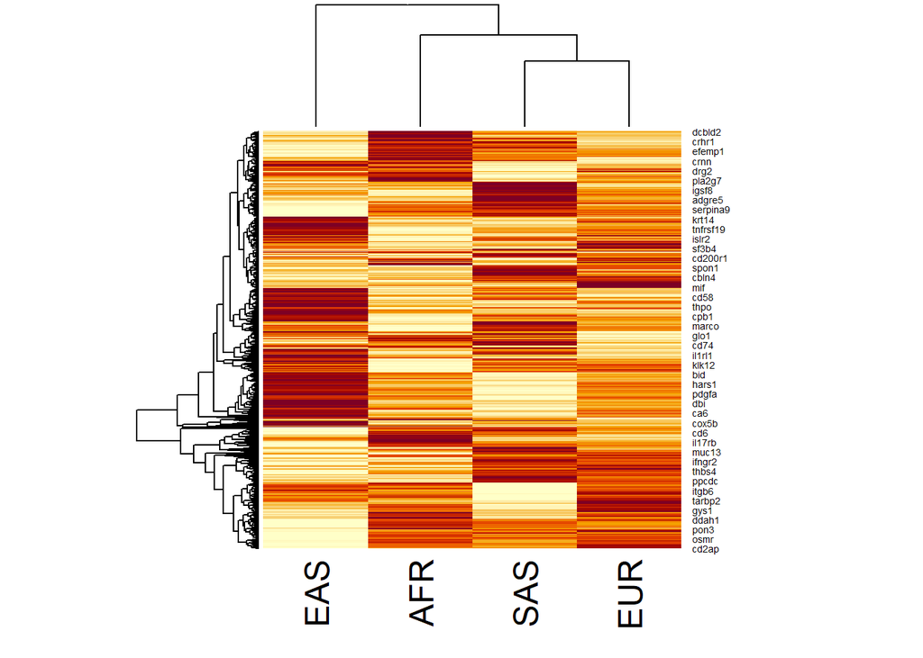

```r
rwm <- as.matrix(rw[,-1])
rownames(rwm) <- unlist(rw[,1])
heatmap(rwm)
```

Perform associations, adjusting for PCs, age etc

```r
phewas_covs <- function(prot4, dat) {
  lapply(names(prot4), function(anc) {
    x <- prot4[[anc]]
    x <- subset(x, id %in% dat$eid)
    ind <- match(x$id, dat$eid)
    d <- dat[ind, ]
    stopifnot(all(d$eid == x$id))
    lapply(4:ncol(x), function(i) {
      o <- summary(lm(x[[i]] ~ d$normscore + d$age_enrollment + d$sex + d$V3 + d$V4 + d$V5 + d$V6 + d$V7 + d$V8 + d$V9 + d$V10 + d$V11 + d$V12))
      tibble(pop = anc, prot = names(x)[i], bhat = o$coef[2,1], se = o$coef[2,2], pval = o$coef[2,4], n = o$df[1] + o$df[2])
    }) %>% bind_rows()
  }) %>% bind_rows()
}


rcovs <- phewas_covs(prot4, dat)
rcovs$fdr <- p.adjust(rcovs$pval, "fdr")
table(rcovs$fdr < 0.05, rcovs$pop)
```

```
##
##          AFR  EAS  EUR  SAS
##   FALSE 1447 1459  731 1427
##   TRUE    16    4  732   36
```

```r
phewas_covs1 <- function(prot4, dat) {
  lapply(names(prot4), \(anc) {
    x <- prot4[[anc]]
    x <- subset(x, id %in% dat$eid)
    ind <- match(x$id, dat$eid)
    d <- dat[ind, ]
    stopifnot(all(d$eid == x$id))
    mclapply(4:ncol(x), \(i) {
      o <- summary(lm(x[[i]] ~ d$normscore + d$age_enrollment + d$sex + d$V3 + d$V4 + d$V5 + d$V6 + d$V7 + d$V8 + d$V9 + d$V10 + d$V11 + d$V12))
      tibble(pop=anc, prot=names(x)[i], bhat=o$coef[2,1], se=o$coef[2,2], pval=o$coef[2,4], n=o$df[1] + o$df[2])
    }) %>% bind_rows()
  }) %>% bind_rows()
}


rcovs1 <- phewas_covs1(prot4, dat)
rcovs1$fdr <- p.adjust(rcovs1$pval, "fdr")
table(rcovs1$fdr < 0.05, rcovs1$pop)
```

```
##
##          AFR  EAS  EUR  SAS
##   FALSE 1447 1459  731 1427
##   TRUE    16    4  732   36
```

## Heterogeneity analysis

```r
fixed_effects_meta_analysis <- function(beta_vec, se_vec) {
    w <- 1 / se_vec^2
    beta <- sum(beta_vec * w, na.rm=T) / sum(w, na.rm=T)
    se <- sqrt(1 / sum(w, na.rm=T))
    pval <- pnorm(abs(beta / se), lower.tail = FALSE)
    Qj <- w * (beta-beta_vec)^2
    Q <- sum(Qj, na.rm=T)
    Qdf <- sum(!is.na(beta_vec))-1
    if(Qdf == 0) Q <- 0
    Qjpval <- pchisq(Qj, 1, lower.tail=FALSE)
    Qpval <- pchisq(Q, Qdf, lower.tail=FALSE)
    return(list(beta=beta, se=se, Q=Q, Qdf=Qdf, Qpval=Qpval, Qj=Qj, Qjpval=Qjpval))
}
```

##Do het analysis for all proteins

```r
rcovs_sig<- subset(rcovs1, fdr < 0.05)
head(rcovs_sig)
```

| pop | prot | bhat | se | pval | n | fdr |
| --- | --- | --- | --- | --- | --- | --- |
| AFR | acta2 | 0.04305324 | 0.01382862 | 0.0018876124 | 1402 | 0.016661097 |
| AFR | agrn | 0.03635754 | 0.01099878 | 0.0009714456 | 1431 | 0.009338419 |
| AFR | alpp | 0.14411760 | 0.04322714 | 0.0008783234 | 1429 | 0.008552327 |
| AFR | ccn5 | 0.03914308 | 0.01422206 | 0.0059935767 | 1433 | 0.045140812 |
| AFR | cd93 | 0.03227781 | 0.01145203 | 0.0048942341 | 1377 | 0.038188077 |
| AFR | cgref1 | 0.05012650 | 0.01671164 | 0.0027518847 | 1418 | 0.023171265 |

```r
table(rcovs_sig$pop)
```

```
##
## AFR EAS EUR SAS
##  16   4 732  36
```

```r
rcovs_sig2 <- subset(rcovs1, prot %in% rcovs_sig$prot)
table(rcovs_sig2$pop)
```

```
##
## AFR EAS EUR SAS
## 748 748 748 748
```

```r
subset(rcovs_sig2, prot == "acta2")
```

| pop | prot | bhat | se | pval | n | fdr |
| --- | --- | --- | --- | --- | --- | --- |
| AFR | acta2 | 0.0430532435 | 0.01382862 | 0.001887612 | 1402 | 0.01666110 |
| EUR | acta2 | -0.0003460163 | 0.00204764 | 0.865810769 | 46632 | 0.96084828 |
| EAS | acta2 | 0.0293653880 | 0.03292176 | 0.373376511 | 235 | 0.73651105 |
| SAS | acta2 | 0.0440846810 | 0.01400735 | 0.001699916 | 956 | 0.01518764 |

```r
fixed_effects_meta_analysis(subset(rcovs_sig2, prot == "acta2")$bhat, subset(rcovs_sig2, prot == "acta2")$se)
```

```
## $beta
## [1] 0.001579139
##
## $se
## [1] 0.002000997
##
## $Q
## [1] 19.79949
##
## $Qdf
## [1] 3
##
## $Qpval
## [1] 0.0001867824
##
## $Qj
## [1] 8.9948940 0.8839431 0.7123504 9.2082977
##
## $Qjpval
## [1] 0.002707350 0.347123974 0.398664646 0.002409206
```

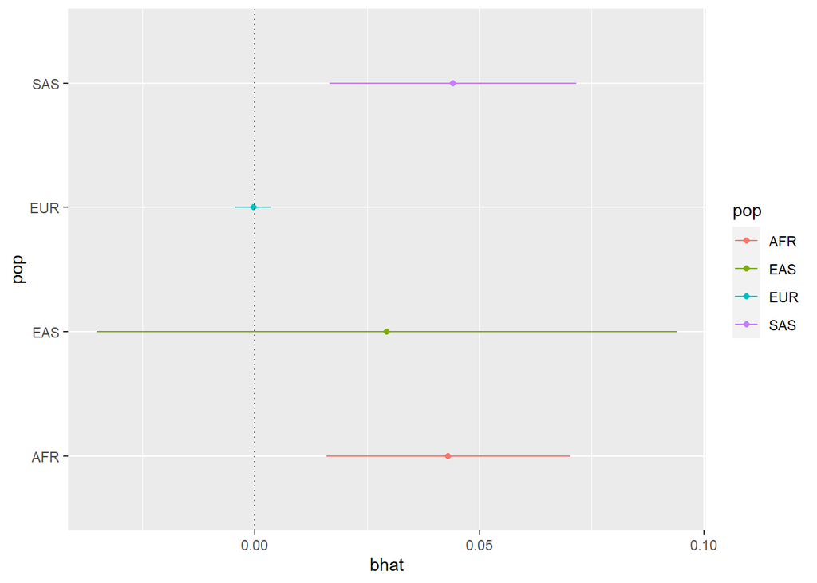

```r
temp <- subset(rcovs_sig2, prot == "acta2")
ggplot(temp, aes(x=bhat, y=pop)) +
  geom_point(aes(colour=pop)) +
  geom_errorbarh(aes(colour=pop, xmin=bhat - se * 1.96, xmax = bhat + se * 1.96), height=0) +
  geom_vline(xintercept=0, linetype="dotted")
```

```r
temp <- subset(rcovs_sig, prot == "acta2")
fixed_effects_meta_analysis(temp$bhat, temp$se)
```

```
## $beta
## [1] 0.04356234
##
## $se
## [1] 0.009840894
##
## $Q
## [1] 0.002745903
##
## $Qdf
## [1] 1
##
## $Qpval
## [1] 0.9582089
##
## $Qj
## [1] 0.001355322 0.001390581
##
## $Qjpval
## [1] 0.9706328 0.9702534
```

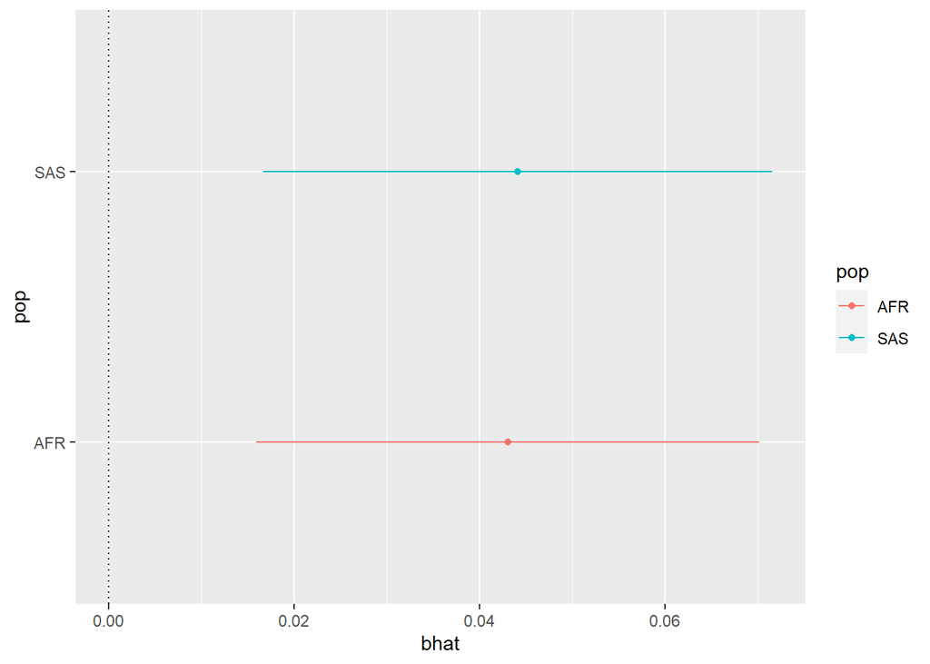

```r
ggplot(temp, aes(x=bhat, y=pop)) +
  geom_point(aes(colour=pop)) +
  geom_errorbarh(aes(colour=pop, xmin=bhat - se * 1.96, xmax = bhat + se * 1.96), height=0) +
  geom_vline(xintercept=0, linetype="dotted")
```

```r
res <- lapply(unique(rcovs_sig2$prot), \(e) {
  x <- subset(rcovs_sig2, prot == e)
  res <- fixed_effects_meta_analysis(x$bhat, x$se)
  Q <- tibble(exposure=e, beta=res$beta, se=res$se, Q=res$Q, Qdf=res$Qdf, Qpval=res$Qpval)
  Qj <- tibble(exposure=e, pop=x$pop, Qj=res$Qj, Qjpval=res$Qjpval)
  return(list(Q,Qj))
})

res[[1]]
```

```
## [[1]]
## # A tibble: 1 × 6
##   exposure   beta      se     Q   Qdf Qpval
##   <chr>     <dbl>   <dbl> <dbl> <dbl> <dbl>
## 1 abl1     0.0161 0.00344  1.12     3 0.771
##
## [[2]]
## # A tibble: 4 × 4
##   exposure pop       Qj Qjpval
##   <chr>    <chr>  <dbl>  <dbl>
## 1 abl1     AFR   0.0122  0.912
## 2 abl1     EUR   0.0302  0.862
## 3 abl1     EAS   0.275   0.600
## 4 abl1     SAS   0.808   0.369
```

```r
resQ <- lapply(res, \(x) x[[1]]) %>% bind_rows()
head(resQ)
```

| exposure | beta | se | Q | Qdf | Qpval |
| --- | --- | --- | --- | --- | --- |
| abl1 | 0.016059939 | 0.003444099 | 1.1249887 | 3 | 0.7710453821 |
| acaa1 | 0.027038059 | 0.004163317 | 0.9900891 | 3 | 0.8036500882 |
| acan | -0.005198983 | 0.001454149 | 7.3747161 | 3 | 0.0608664357 |
| ace2 | 0.022952968 | 0.002619105 | 4.2814603 | 3 | 0.2326316613 |
| acp5 | 0.013136671 | 0.001630130 | 3.1870084 | 3 | 0.3636810843 |
| acta2 | 0.001579139 | 0.002000997 | 19.7994851 | 3 | 0.0001867824 |

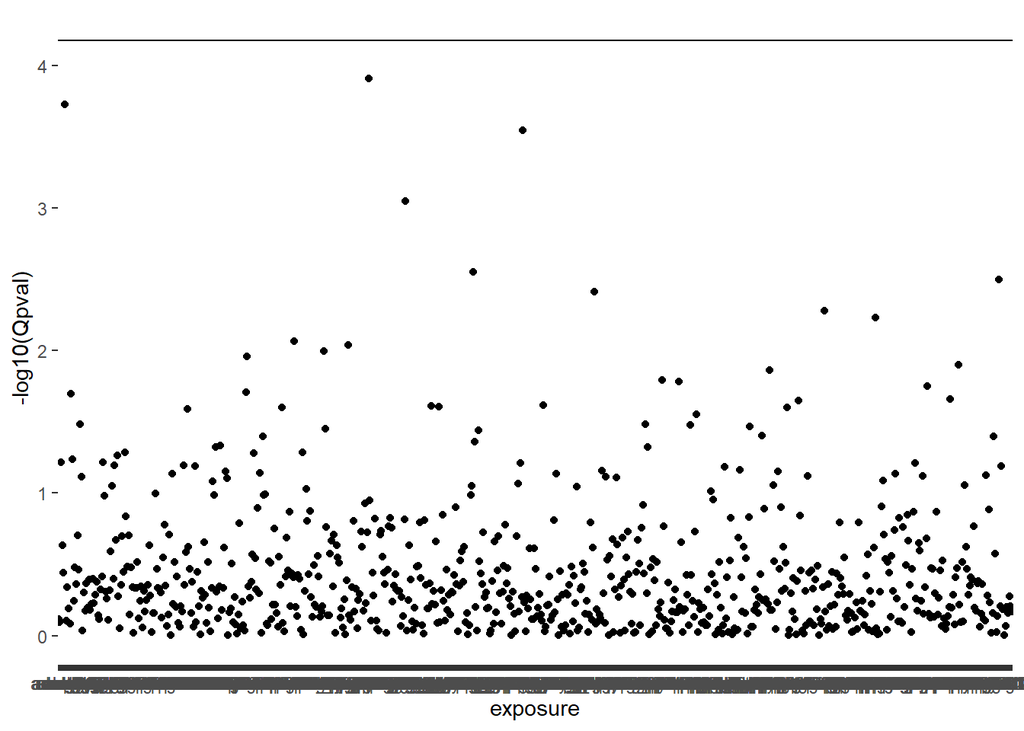

```r
resQ$fdr <- p.adjust(resQ$Qpval, "fdr")
ggplot(resQ, aes(x=exposure, y=-log10(Qpval))) +
  geom_point() +
  geom_hline(yintercept=-log10(0.05/length(unique(rcovs_sig$prot))))
```

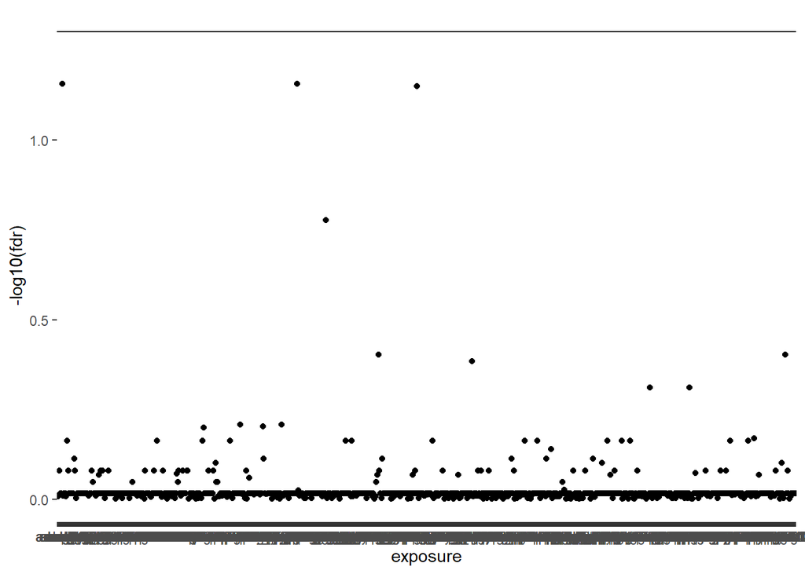

```r
resQ$fdr <- p.adjust(resQ$Qpval, "fdr")
ggplot(resQ, aes(x=exposure, y=-log10(fdr))) +
  geom_point() +
  geom_hline(yintercept=-log10(0.05))
```

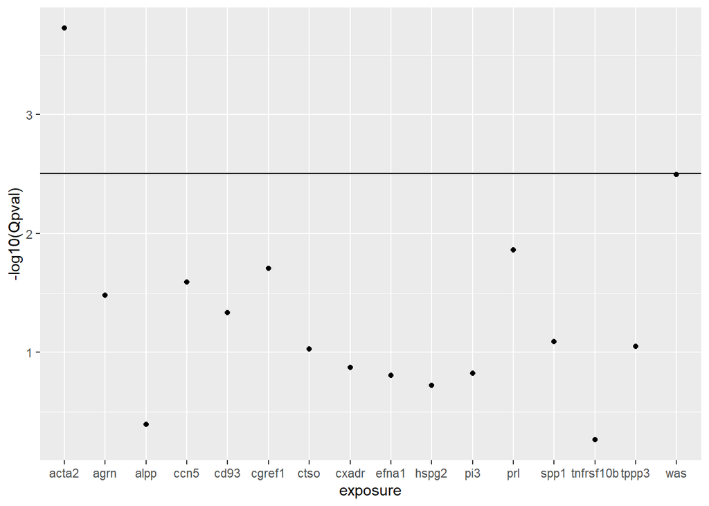

```r
afr_sig <- subset(rcovs_sig, pop=="AFR")$prot

ggplot(resQ %>% filter(exposure %in% afr_sig), aes(x=exposure, y=-log10(Qpval))) +
  geom_point() +
  geom_hline(yintercept=-log10(0.05/length(unique(afr_sig))))
```

# Organise the results for per-study heterogeneity contributions (Qj)

```r
resQj <- lapply(res, \(x) x[[2]]) %>% bind_rows()

# Correct for multiple testing using FDR
resQj$fdr <- p.adjust(resQj$Qjpval, "fdr")
```

# Visualise the per-study heterogeneity (pval)

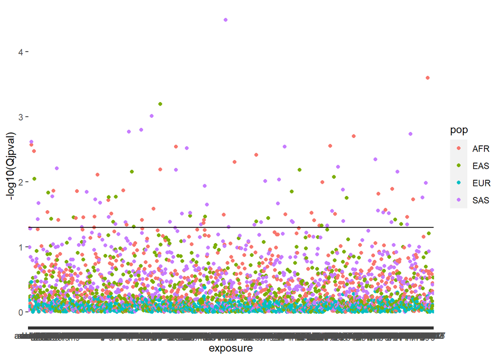

```r
ggplot(resQj, aes(x=exposure, y=-log10(Qjpval))) +
geom_point(aes(colour=pop)) +
geom_hline(yintercept=-log10(0.05))
```

# Visualise the per-study heterogeneity (FDR)

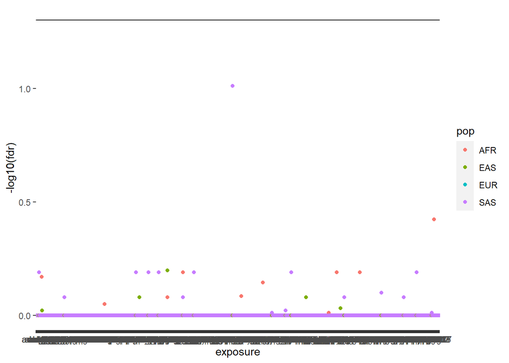

```r
ggplot(resQj, aes(x=exposure, y=-log10(fdr))) +
geom_point(aes(colour=pop)) +
geom_hline(yintercept=-log10(0.05))
```

For each of AFR, SAS and EAS, select their significant proteins, and perform heterogeneity (like in rcovs_sig2), to see if there’s any evidence that these are ancestry specific

Choosing only significant proteins in the African ancestry

```r
selected_pop <- rcovs_sig %>%
  filter(pop %in% c("AFR")) %>%
  select(prot)

dim(selected_pop)
```

```
## [1] 16  1
```

Obtaining protein information for all

```r
selected_pop_all <- subset(rcovs1, prot %in% selected_pop$prot)
table(selected_pop_all$pop)
```

```
##
## AFR EAS EUR SAS
##  16  16  16  16
```

Do heterogeneity analysis for all significant proteins in African ancestry for all ancestries

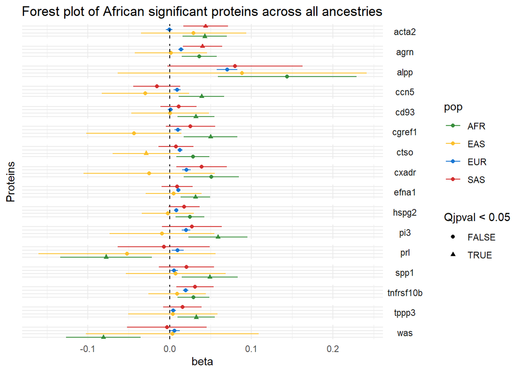

```r
res <- lapply(unique(selected_pop_all$prot), \(e) {
  x <- subset(selected_pop_all, prot == e)
  res <- fixed_effects_meta_analysis(x$bhat, x$se)
  Q <- tibble(exposure=e, beta=res$beta, se=res$se, Q=res$Q, Qdf=res$Qdf, Qpval=res$Qpval)
  Qj <- tibble(exposure=e, pop=x$pop, Qj=res$Qj, Qjpval=res$Qjpval)
  return(list(Q,Qj))
})

resQ <- lapply(res, \(x) x[[1]]) %>% bind_rows()


# Organise the results for per-study heterogeneity contributions (Qj)

resQj <- lapply(res, \(x) x[[2]]) %>% bind_rows()

# Correct for multiple testing using FDR
resQj$fdr <- p.adjust(resQj$Qjpval, "fdr")

res_m <- inner_join(selected_pop_all, resQj, by=c("prot"="exposure", "pop"))


names(resQ)[names(resQ)=="beta"] <- "b"
resQ$pop <- "Combined"
resQ$Qjpval <- 1


# Define a custom color palette
custom_colors <- c("SAS" = "#D32F2F", "EUR" = "#1976D2", "AFR" = "#388E3C", "EAS" = "#FBC02D")



ggplot(res_m, aes(y=pop, x=bhat, color=pop)) +
  geom_point(aes(shape=Qjpval < 0.05)) +
  geom_errorbarh(aes(xmin=bhat-se*1.96, xmax=bhat+se*1.96), height=0) +
  geom_vline(xintercept=0, linetype="dashed") +
  labs(title = "Forest plot of African significant proteins across all ancestries",
       x = "beta",
       y = "Proteins") +
   facet_grid(prot ~ .)+
   theme_minimal() +  # Apply a minimal theme
  theme(
    plot.title = element_text(hjust = 0.5), # Center the plot title
    axis.text.y=element_blank(), # remove y axis text
    strip.text.y=element_text(angle=0)
  ) +
  scale_colour_manual(values=custom_colors)
```

Choosing only significant proteins in the EAS ancestry

```r
selected_pop <- rcovs_sig %>%
  filter(pop %in% c("EAS")) %>%
  select(prot)

dim(selected_pop)
```

```
## [1] 4 1
```

Obtaining protein information for all

```r
selected_pop_all <- subset(rcovs1, prot %in% selected_pop$prot)
table(selected_pop_all$pop)
```

```
##
## AFR EAS EUR SAS
##   4   4   4   4
```

Do heterogeneity analysis for all significant proteins in EAS ancestry for all ancestries

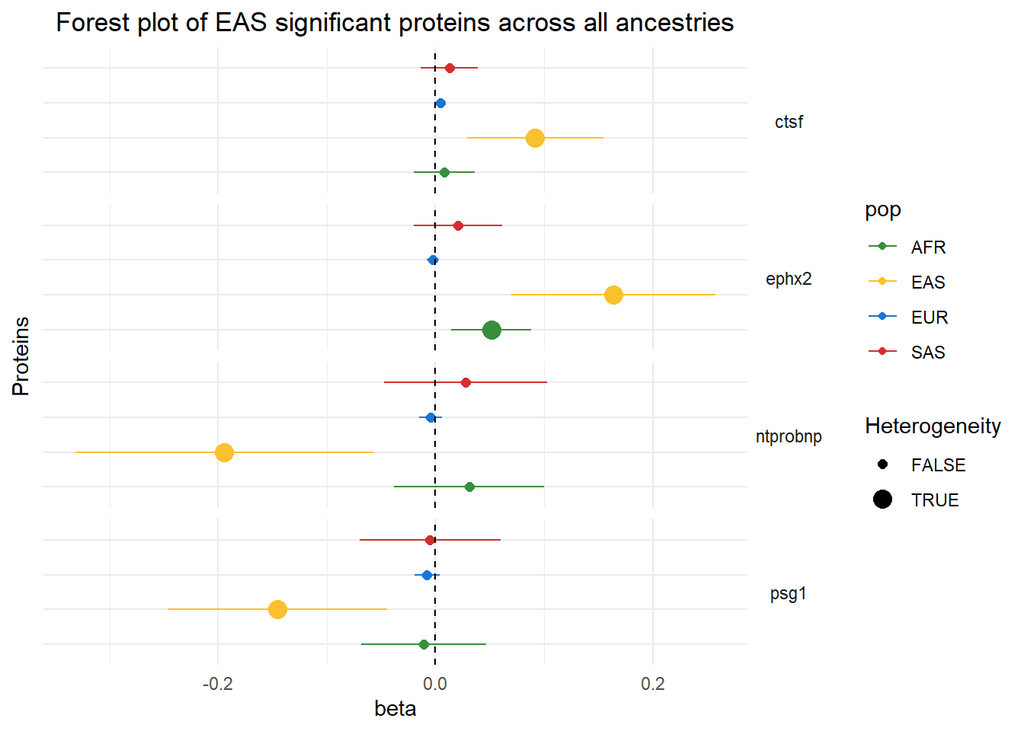

```r
res <- lapply(unique(selected_pop_all$prot), \(e) {
  x <- subset(selected_pop_all, prot == e)
  res <- fixed_effects_meta_analysis(x$bhat, x$se)
  Q <- tibble(exposure=e, beta=res$beta, se=res$se, Q=res$Q, Qdf=res$Qdf, Qpval=res$Qpval)
  Qj <- tibble(exposure=e, pop=x$pop, Qj=res$Qj, Qjpval=res$Qjpval)
  return(list(Q,Qj))
})

resQ <- lapply(res, \(x) x[[1]]) %>% bind_rows()



# Organise the results for per-study heterogeneity contributions (Qj)

resQj <- lapply(res, \(x) x[[2]]) %>% bind_rows()

# Correct for multiple testing using FDR
resQj$fdr <- p.adjust(resQj$Qjpval, "fdr")

res_m <- inner_join(selected_pop_all, resQj, by=c("prot"="exposure", "pop"))


names(resQ)[names(resQ)=="beta"] <- "b"
resQ$pop <- "Combined"
resQ$Qjpval <- 1


# Define a custom color palette
custom_colors <- c("SAS" = "#D32F2F", "EUR" = "#1976D2", "AFR" = "#388E3C", "EAS" = "#FBC02D")



ggplot(res_m, aes(y=pop, x=bhat, color=pop)) +
  geom_point(aes(size=Qjpval < 0.05)) +
  geom_errorbarh(aes(xmin=bhat-se*1.96, xmax=bhat+se*1.96), height=0) +
  geom_vline(xintercept=0, linetype="dashed") +
  labs(title = "Forest plot of EAS significant proteins across all ancestries",
       x = "beta",
       y = "Proteins") +
   facet_grid(prot ~ .)+
   theme_minimal() +  # Apply a minimal theme
  theme(
    plot.title = element_text(hjust = 0.5), # Center the plot title
    axis.text.y=element_blank(), # remove y axis text
    strip.text.y=element_text(angle=0)
  ) +
  scale_colour_manual(values=custom_colors) +
  scale_size_manual(
    values=c("FALSE"=2, "TRUE"=4),
    guide=guide_legend(title="Heterogeneity",
                       override.aes=list(shape=c(16,16))))
```

Choosing only significant proteins in the SAS ancestry

```r
selected_pop <- rcovs_sig %>%
  filter(pop %in% c("SAS")) %>%
  select(prot)

dim(selected_pop)
```

```
## [1] 36  1
```

Obtaining protein information for all

```r
selected_pop_all <- subset(rcovs1, prot %in% selected_pop$prot)
table(selected_pop_all$pop)
```

```
##
## AFR EAS EUR SAS
##  36  36  36  36
```

Do heterogeneity analysis for all significant proteins in SAS ancestry for all ancestries

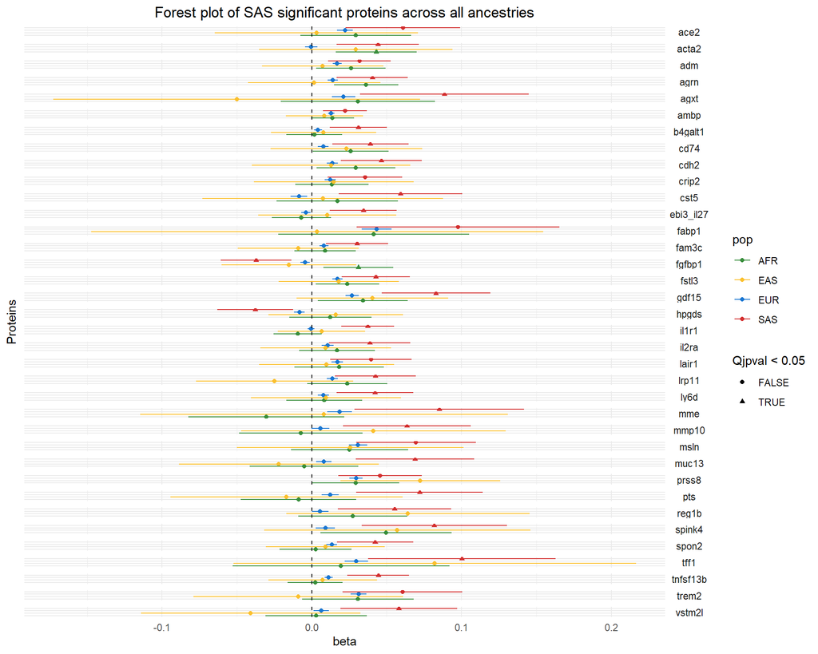

```r
res <- lapply(unique(selected_pop_all$prot), \(e) {
  x <- subset(selected_pop_all, prot == e)
  res <- fixed_effects_meta_analysis(x$bhat, x$se)
  Q <- tibble(exposure=e, beta=res$beta, se=res$se, Q=res$Q, Qdf=res$Qdf, Qpval=res$Qpval)
  Qj <- tibble(exposure=e, pop=x$pop, Qj=res$Qj, Qjpval=res$Qjpval)
  return(list(Q,Qj))
})

resQ <- lapply(res, \(x) x[[1]]) %>% bind_rows()



# Organise the results for per-study heterogeneity contributions (Qj)

resQj <- lapply(res, \(x) x[[2]]) %>% bind_rows()

# Correct for multiple testing using FDR
resQj$fdr <- p.adjust(resQj$Qjpval, "fdr")

res_m <- inner_join(selected_pop_all, resQj, by=c("prot"="exposure", "pop"))


names(resQ)[names(resQ)=="beta"] <- "b"
resQ$pop <- "Combined"
resQ$Qjpval <- 1


# Define a custom color palette
custom_colors <- c("SAS" = "#D32F2F", "EUR" = "#1976D2", "AFR" = "#388E3C", "EAS" = "#FBC02D")



ggplot(res_m, aes(y=pop, x=bhat, color=pop)) +
  geom_point(aes(shape=Qjpval < 0.05)) +
  geom_errorbarh(aes(xmin=bhat-se*1.96, xmax=bhat+se*1.96), height=0) +
  geom_vline(xintercept=0, linetype="dashed") +
  labs(title = "Forest plot of SAS significant proteins across all ancestries",
       x = "beta",
       y = "Proteins") +
   facet_grid(prot ~ .)+
   theme_minimal() +  # Apply a minimal theme
  theme(
    plot.title = element_text(hjust = 0.5), # Center the plot title
    axis.text.y=element_blank(), # remove y axis text
    strip.text.y=element_text(angle=0)
  ) +
  scale_colour_manual(values=custom_colors)
```

Obtaining protein names that are significant in EAS, SAS and AFR

```r
selected_pop <- rcovs_sig %>%
  filter(pop %in% c("AFR", "SAS", "EAS")) %>%
  select(prot)

dim(selected_pop)
```

```
## [1] 56  1
```

Obtaining protein information for all

```r
selected_pop_all <- subset(rcovs1, prot %in% selected_pop$prot)
table(selected_pop_all$pop)
```

```
##
## AFR EAS EUR SAS
##  54  54  54  54
```

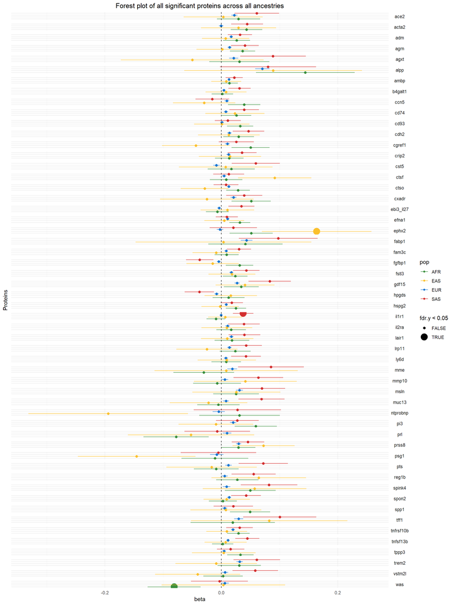

```r
res <- lapply(unique(selected_pop_all$prot), \(e) {
  x <- subset(selected_pop_all, prot == e)
  res <- fixed_effects_meta_analysis(x$bhat, x$se)
  Q <- tibble(exposure=e, beta=res$beta, se=res$se, Q=res$Q, Qdf=res$Qdf, Qpval=res$Qpval)
  Qj <- tibble(exposure=e, pop=x$pop, Qj=res$Qj, Qjpval=res$Qjpval)
  return(list(Q,Qj))
})

resQ <- lapply(res, \(x) x[[1]]) %>% bind_rows()



# Organise the results for per-study heterogeneity contributions (Qj)

resQj <- lapply(res, \(x) x[[2]]) %>% bind_rows()

# Correct for multiple testing using FDR
resQj$fdr <- p.adjust(resQj$Qjpval, "fdr")

res_m <- inner_join(selected_pop_all, resQj, by=c("prot"="exposure", "pop"))


names(resQ)[names(resQ)=="beta"] <- "b"
resQ$pop <- "Combined"
resQ$Qjpval <- 1


# Define a custom color palette
custom_colors <- c("SAS" = "#D32F2F", "EUR" = "#1976D2", "AFR" = "#388E3C", "EAS" = "#FBC02D")



ggplot(res_m, aes(y=pop, x=bhat, color=pop)) +
  geom_point(aes(size=fdr.y < 0.05)) +
  geom_errorbarh(aes(xmin=bhat-se*1.96, xmax=bhat+se*1.96), height=0) +
  geom_vline(xintercept=0, linetype="dashed") +
  labs(title = "Forest plot of all significant proteins across all ancestries",
       x = "beta",
       y = "Proteins") +
   facet_grid(prot ~ .)+
   theme_minimal() +  # Apply a minimal theme
  theme(
    plot.title = element_text(hjust = 0.5), # Center the plot title
    axis.text.y=element_blank(), # remove y axis text
    strip.text.y=element_text(angle=0)
  ) +
  scale_colour_manual(values=custom_colors)
```

The forest plot is too long, the following analysis is for per ancestry significant proteins for all across all ancestries except EUR.

Choosing only significant proteins in the SAS ancestry

```r
selected_pop_SAS <- rcovs_sig %>%
  filter(pop %in% "SAS") %>%
  select(prot)

dim(selected_pop_SAS)
```

```
## [1] 36  1
```

Obtaining protein information for all

```r
selected_pop_SAS_all <- subset(res_m, prot %in% selected_pop_SAS$prot)
table(selected_pop_SAS_all$pop)
```

```
##
## AFR EAS EUR SAS
##  36  36  36  36
```

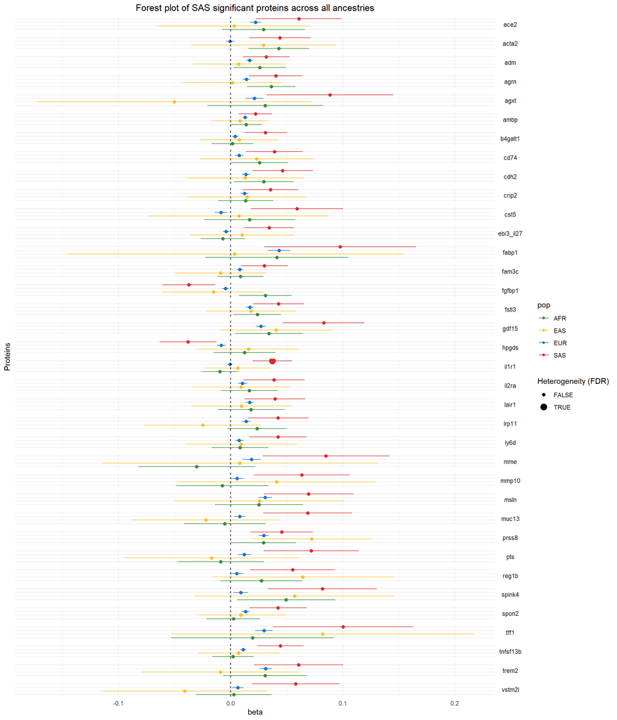

```r
ggplot(selected_pop_SAS_all, aes(y=pop, x=bhat, color=pop)) +
  geom_point(aes(size =fdr.y < 0.05)) +
  geom_errorbarh(aes(xmin=bhat-se*1.96, xmax=bhat+se*1.96), height=0) +
  geom_vline(xintercept=0, linetype="dashed") +
  labs(title = "Forest plot of SAS significant proteins across all ancestries",
       x = "beta",
       y = "Proteins") +
   facet_grid(prot ~ .)+
   theme_minimal() +  # Apply a minimal theme
  theme(
    plot.title = element_text(hjust = 0.5), # Center the plot title
    axis.text.y=element_blank(), # remove y axis text
    strip.text.y=element_text(angle=0)
  ) +
  scale_colour_manual(values=custom_colors) +
  scale_size_manual(
    values=c("FALSE"=2, "TRUE"=4),
    guide=guide_legend(title="Heterogeneity (FDR)",
                       override.aes=list(shape=c(16,16))))
```

Choosing only significant proteins in the EAS ancestry

```r
selected_pop_eas <- rcovs_sig %>%
  filter(pop %in% "EAS") %>%
  select(prot)

dim(selected_pop_eas)
```

```
## [1] 4 1
```

Obtaining protein information for all

```r
selected_pop_eas_all <- subset(res_m, prot %in% selected_pop_eas$prot)
table(selected_pop_eas_all$pop)
```

```
##
## AFR EAS EUR SAS
##   4   4   4   4
```

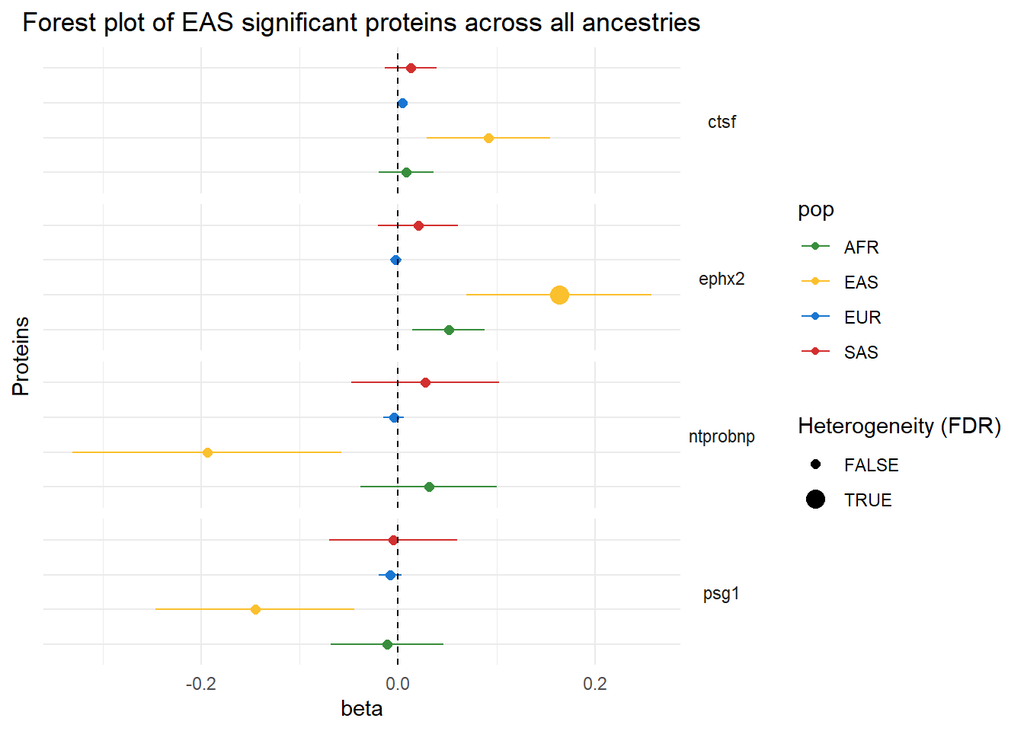

```r
ggplot(selected_pop_eas_all, aes(y=pop, x=bhat, color=pop)) +
  geom_point(aes(size =fdr.y < 0.05)) +
  geom_errorbarh(aes(xmin=bhat-se*1.96, xmax=bhat+se*1.96), height=0) +
  geom_vline(xintercept=0, linetype="dashed") +
  labs(title = "Forest plot of EAS significant proteins across all ancestries",
       x = "beta",
       y = "Proteins") +
   facet_grid(prot ~ .)+
   theme_minimal() +  # Apply a minimal theme
  theme(
    plot.title = element_text(hjust = 0.5), # Center the plot title
    axis.text.y=element_blank(), # remove y axis text
    strip.text.y=element_text(angle=0)
  ) +
  scale_colour_manual(values=custom_colors) +
  scale_size_manual(
    values=c("FALSE"=2, "TRUE"=4),
    guide=guide_legend(title="Heterogeneity (FDR)",
                       override.aes=list(shape=c(16,16))))
```

```r
selected_pop_afr <- rcovs_sig %>%
  filter(pop %in% "AFR") %>%
  select(prot)

dim(selected_pop_afr)
```

```
## [1] 16  1
```

Obtaining protein information for all

```r
selected_pop_afr_all <- subset(res_m, prot %in% selected_pop_afr$prot)
table(selected_pop_afr_all$pop)
```

```
##
## AFR EAS EUR SAS
##  16  16  16  16
```

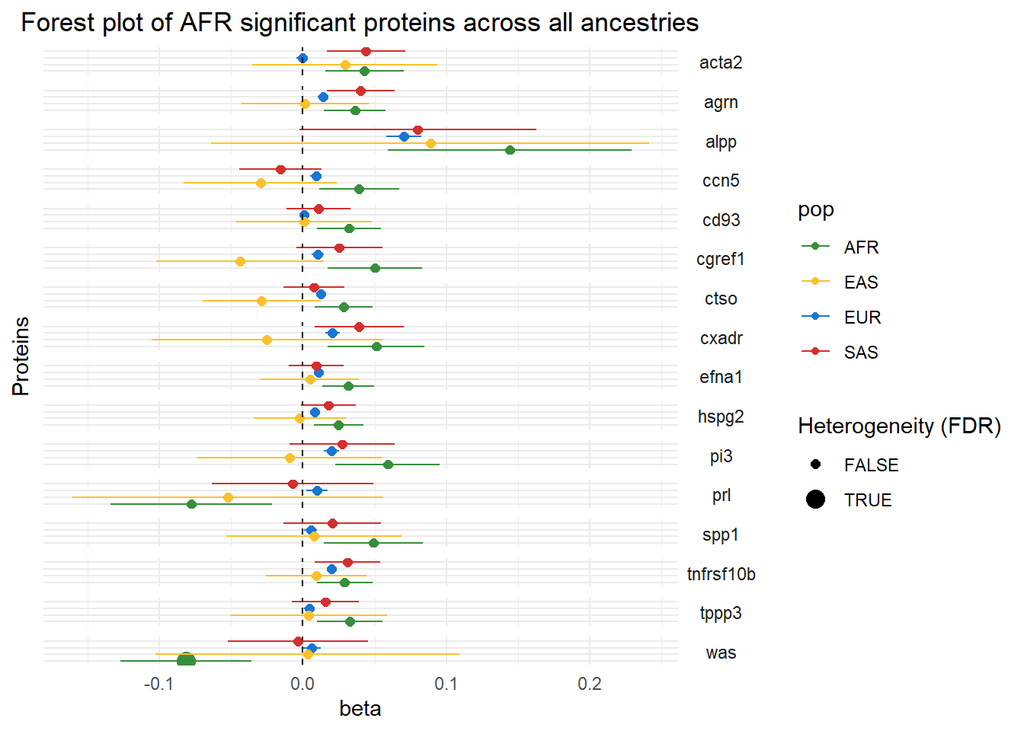

```r
ggplot(selected_pop_afr_all, aes(y=pop, x=bhat, color=pop)) +
  geom_point(aes(size =fdr.y < 0.05)) +
  geom_errorbarh(aes(xmin=bhat-se*1.96, xmax=bhat+se*1.96), height=0) +
  geom_vline(xintercept=0, linetype="dashed") +
  labs(title = "Forest plot of AFR significant proteins across all ancestries",
       x = "beta",
       y = "Proteins") +
   facet_grid(prot ~ .)+
   theme_minimal() +  # Apply a minimal theme
  theme(
    plot.title = element_text(hjust = 0.5), # Center the plot title
    axis.text.y=element_blank(), # remove y axis text
    strip.text.y=element_text(angle=0)
  ) +
  scale_colour_manual(values=custom_colors) +
  scale_size_manual(
    values=c("FALSE"=2, "TRUE"=4),
    guide=guide_legend(title="Heterogeneity (FDR)",
                       override.aes=list(shape=c(16,16))))
```

## Expected vs observed replication

Take significant results from EUR Even though the power is lower in other populations, is the degree of association high enough to suggest that overall, the effects are the same

```r
evso <- function(b_disc, b_rep, se_disc, se_rep, alpha)
{
  p_sign <- pnorm(-abs(b_disc) / se_disc) * pnorm(-abs(b_disc) / se_rep) + ((1 - pnorm(-abs(b_disc) / se_disc)) * (1 - pnorm(-abs(b_disc) / se_rep)))
  p_sig <- pnorm(-abs(b_disc) / se_rep + qnorm(alpha / 2)) + (1 - pnorm(-abs(b_disc) / se_rep - qnorm(alpha / 2)))
  p_rep <- pnorm(abs(b_rep)/se_rep, lower.tail=FALSE)
  res <- tibble::tibble(
    nsnp=length(b_disc),
    metric=c("Sign", "Sign", "P-value", "P-value"),
    datum=c("Expected", "Observed", "Expected", "Observed"),
    value=c(sum(p_sign, na.rm=TRUE), sum(sign(b_disc) == sign(b_rep)), sum(p_sig, na.rm=TRUE), sum(p_rep < alpha, na.rm=TRUE))
  )
  return(list(res=res, variants=dplyr::tibble(sig=p_sig, sign=p_sign)))
}
```

EUR vs AFR

```r
eur_prot <- subset(rcovs_sig, pop == "EUR")$prot
temp1 <- rcovs1[rcovs1$pop == "EUR" & rcovs1$prot %in% eur_prot, ]
temp2 <- rcovs1[rcovs1$pop == "AFR" & rcovs1$prot %in% eur_prot, ]
evso(b_disc = temp1$bhat, b_rep = temp2$bhat, se_disc = temp1$se, se_rep = temp2$se, 0.05)
```

```
## $res
## # A tibble: 4 × 4
##    nsnp metric  datum    value
##   <int> <chr>   <chr>    <dbl>
## 1   732 Sign    Expected  564.
## 2   732 Sign    Observed  488
## 3   732 P-value Expected  101.
## 4   732 P-value Observed  148
##
## $variants
## # A tibble: 732 × 2
##       sig  sign
##     <dbl> <dbl>
##  1 0.110  0.762
##  2 0.165  0.836
##  3 0.0868 0.713
##  4 0.217  0.880
##  5 0.218  0.881
##  6 0.217  0.880
##  7 0.178  0.849
##  8 0.367  0.947
##  9 0.126  0.788
## 10 0.221  0.883
## # ℹ 722 more rows
```

AFR vs EUR

```r
afr_prot <- subset(rcovs_sig, pop == "AFR")$prot
temp1 <- rcovs1[rcovs1$pop == "AFR" & rcovs1$prot %in% afr_prot, ]
temp2 <- rcovs1[rcovs1$pop == "EUR" & rcovs1$prot %in% afr_prot, ]
evso(b_disc = temp1$bhat, b_rep = temp2$bhat, se_disc = temp1$se, se_rep = temp2$se, 0.05)
```

```
## $res
## # A tibble: 4 × 4
##    nsnp metric  datum    value
##   <int> <chr>   <chr>    <dbl>
## 1    16 Sign    Expected  16.0
## 2    16 Sign    Observed  13
## 3    16 P-value Expected  16
## 4    16 P-value Observed  14
##
## $variants
## # A tibble: 16 × 2
##      sig  sign
##    <dbl> <dbl>
##  1     1 0.999
##  2     1 1.00
##  3     1 1.00
##  4     1 0.997
##  5     1 0.998
##  6     1 0.999
##  7     1 0.997
##  8     1 0.999
##  9     1 1.00
## 10     1 0.997
## 11     1 0.999
## 12     1 0.997
## 13     1 0.997
## 14     1 0.998
## 15     1 0.998
## 16     1 1.00
```

EUR vs SAS

```r
eur_prot <- subset(rcovs_sig, pop == "EUR")$prot
temp1 <- rcovs1[rcovs1$pop == "EUR" & rcovs1$prot %in% eur_prot, ]
temp2 <- rcovs1[rcovs1$pop == "SAS" & rcovs1$prot %in% eur_prot, ]
evso(b_disc = temp1$bhat, b_rep = temp2$bhat, se_disc = temp1$se, se_rep = temp2$se, 0.05)
```

```
## $res
## # A tibble: 4 × 4
##    nsnp metric  datum    value
##   <int> <chr>   <chr>    <dbl>
## 1   732 Sign    Expected 557.
## 2   732 Sign    Observed 496
## 3   732 P-value Expected  95.7
## 4   732 P-value Observed 195
##
## $variants
## # A tibble: 732 × 2
##       sig  sign
##     <dbl> <dbl>
##  1 0.0987 0.740
##  2 0.142  0.810
##  3 0.0811 0.697
##  4 0.206  0.872
##  5 0.194  0.862
##  6 0.197  0.865
##  7 0.155  0.826
##  8 0.374  0.949
##  9 0.107  0.757
## 10 0.211  0.875
## # ℹ 722 more rows
```

SAS vs EUR

```r
sas_prot <- subset(rcovs_sig, pop == "SAS")$prot
temp1 <- rcovs1[rcovs1$pop == "SAS" & rcovs1$prot %in% sas_prot, ]
temp2 <- rcovs1[rcovs1$pop == "EUR" & rcovs1$prot %in% sas_prot, ]
evso(b_disc = temp1$bhat, b_rep = temp2$bhat, se_disc = temp1$se, se_rep = temp2$se, 0.05)
```

```
## $res
## # A tibble: 4 × 4
##    nsnp metric  datum    value
##   <int> <chr>   <chr>    <dbl>
## 1    36 Sign    Expected  36.0
## 2    36 Sign    Observed  32
## 3    36 P-value Expected  36
## 4    36 P-value Observed  34
##
## $variants
## # A tibble: 36 × 2
##      sig  sign
##    <dbl> <dbl>
##  1     1 0.999
##  2     1 0.999
##  3     1 0.999
##  4     1 1.00
##  5     1 0.999
##  6     1 0.998
##  7     1 0.999
##  8     1 0.999
##  9     1 1.00
## 10     1 0.998
## # ℹ 26 more rows
```

EUR vs EAS

```r
eur_prot <- subset(rcovs_sig, pop == "EUR")$prot
temp1 <- rcovs1[rcovs1$pop == "EUR" & rcovs1$prot %in% eur_prot, ]
temp2 <- rcovs1[rcovs1$pop == "EAS" & rcovs1$prot %in% eur_prot, ]
evso(b_disc = temp1$bhat, b_rep = temp2$bhat, se_disc = temp1$se, se_rep = temp2$se, 0.05)
```

```
## $res
## # A tibble: 4 × 4
##    nsnp metric  datum    value
##   <int> <chr>   <chr>    <dbl>
## 1   732 Sign    Expected 474.
## 2   732 Sign    Observed 480
## 3   732 P-value Expected  52.4
## 4   732 P-value Observed  52
##
## $variants
## # A tibble: 732 × 2
##       sig  sign
##     <dbl> <dbl>
##  1 0.0614 0.623
##  2 0.0676 0.652
##  3 0.0587 0.608
##  4 0.0984 0.740
##  5 0.0873 0.714
##  6 0.0944 0.731
##  7 0.0773 0.686
##  8 0.126  0.789
##  9 0.0660 0.645
## 10 0.0848 0.707
## # ℹ 722 more rows
```

EAS vs EUR

```r
eas_prot <- subset(rcovs_sig, pop == "EAS")$prot
temp1 <- rcovs1[rcovs1$pop == "EAS" & rcovs1$prot %in% eas_prot, ]
temp2 <- rcovs1[rcovs1$pop == "EUR" & rcovs1$prot %in% eas_prot, ]
evso(b_disc = temp1$bhat, b_rep = temp2$bhat, se_disc = temp1$se, se_rep = temp2$se, 0.05)
```

```
## $res
## # A tibble: 4 × 4
##    nsnp metric  datum    value
##   <int> <chr>   <chr>    <dbl>
## 1     4 Sign    Expected  3.99
## 2     4 Sign    Observed  3
## 3     4 P-value Expected  4
## 4     4 P-value Observed  1
##
## $variants
## # A tibble: 4 × 2
##     sig  sign
##   <dbl> <dbl>
## 1     1 0.998
## 2     1 1.00
## 3     1 0.997
## 4     1 0.998
```